# Analysis of willow leaf beetle system for github sharing

– History 1: During analyses using version 2, an error was discovered in the Une-level data aggregation of version 1. In addition, the data aggregation method used in version 2 was found to be inconvenient for analysis. Therefore, starting on 2025/05/11, version 3 was initiated by copying the contents of version 2 and continuing development from there.

– History 2: Subsequently, in order to remove analysis components unnecessary for manuscript preparation, the version 3 at 2026/02/04 was copied as version 4. Updates to version 3 were discontinued, and generation and modification of version 4 were initiated.

– History 3: The version 4 was copied to version 5 for github sharing

## Outline

1 Prearrangement  
2 Non-spatial data summary at the section level  
3 Non-spatial data summary at the une level  
4 Visualization of time evolution w/o spatial info  
5 Visualization and quantification of spatial information  
6 Autoregression model w/ unequal intervals

## [1] Prearrangement

### [1.1] Loading packages

```r
R.version
```

```
               _
platform       x86_64-w64-mingw32
arch           x86_64
os             mingw32
crt            ucrt
system         x86_64, mingw32
status
major          4
minor          5.3
year           2026
month          03
day            11
svn rev        89597
language       R
version.string R version 4.5.3 (2026-03-11 ucrt)
nickname       Reassured Reassurer
```

```r
Sys.setlocale("LC_ALL", "English")
```

```
[1] "LC_COLLATE=English_United States.1252;LC_CTYPE=English_United States.1252;LC_MONETARY=English_United States.1252;LC_NUMERIC=C;LC_TIME=English_United States.1252"
```

```r
library(vegan)
library(epiphy)
library(car)
library(zoo)
library(ggplot2)
library(gganimate)
library(patchwork)
library(gifski)
library(png)
library(rgl)
library(animation)
library(dplyr)
library(nlme) #for using gls()
library(spdep) # Moran's I
source("C:/Users/biomiki/Dropbox/r_local/plot_mod_epiphy.R")
```

### [1.2] Loading Data and site stratification (compartmentalization) IDs

```r
aphid2024april <- read.csv("aphid_population_2024_Apr.csv", header = T)
head(aphid2024april)
```

|  | dayID | YY.MM.DD | month | day | dayN | x | y | section | intrasection_plantID | aphid |
| --- | --- | --- | --- | --- | --- | --- | --- | --- | --- | --- |
| 1 | s01 | 24-04-04 | M04 | D04 | 4 | 0 | 0 | sec01 | ind001 | NA |
| 2 | s01 | 24-04-04 | M04 | D04 | 4 | 0 | -10 | sec01 | ind002 | 1 |
| 3 | s01 | 24-04-04 | M04 | D04 | 4 | 0 | -20 | sec01 | ind003 | NA |
| 4 | s01 | 24-04-04 | M04 | D04 | 4 | 0 | -30 | sec01 | ind004 | NA |
| 5 | s01 | 24-04-04 | M04 | D04 | 4 | 0 | -40 | sec01 | ind005 | NA |
| 6 | s01 | 24-04-04 | M04 | D04 | 4 | 0 | -50 | sec01 | ind006 | NA |

```r
# converting NA to zero
aphid2024april$aphid[is.na(aphid2024april$aphid)] <- 0
head(aphid2024april)
```

|  | dayID | YY.MM.DD | month | day | dayN | x | y | section | intrasection_plantID | aphid |
| --- | --- | --- | --- | --- | --- | --- | --- | --- | --- | --- |
| 1 | s01 | 24-04-04 | M04 | D04 | 4 | 0 | 0 | sec01 | ind001 | 0 |
| 2 | s01 | 24-04-04 | M04 | D04 | 4 | 0 | -10 | sec01 | ind002 | 1 |
| 3 | s01 | 24-04-04 | M04 | D04 | 4 | 0 | -20 | sec01 | ind003 | 0 |
| 4 | s01 | 24-04-04 | M04 | D04 | 4 | 0 | -30 | sec01 | ind004 | 0 |
| 5 | s01 | 24-04-04 | M04 | D04 | 4 | 0 | -40 | sec01 | ind005 | 0 |
| 6 | s01 | 24-04-04 | M04 | D04 | 4 | 0 | -50 | sec01 | ind006 | 0 |

```r
ind_ID <- read.csv("ind_ID.csv", header = F)
une_ID <- read.csv("une_ID.csv", header = F)
A_ID <- read.csv("A_ID.csv", header = F)
B_ID <- read.csv("B_ID.csv", header = F)
Bd_ID <- read.csv("Bd_ID.csv", header = F) # We finally decided to focus on this setting only
C_ID <- read.csv("C_ID.csv", header = F)
Cd_ID <- read.csv("Cd_ID.csv", header = F)
D_ID <- read.csv("D_ID.csv", header = F)
```

### [1.3] Functions to characterize population dynamics

```r
# Function to calculte the proportion with which plant individuals are under herbivory (= prevalence).
prevalence <- function(vec) {
  temp <- sum(vec > 0) / length(vec)
  return(temp)
}

# Function to calculte specific growth rate (/day) from the input quantity (either population size or prevalence)
# mathematical definition：r(k) = ln(N(k+tau)) - ln(N(k+tau-1)) / time_interval
# tau: time delay, can be negative and zero
specific_growth <- function(value_vec, time_vec, tau = 1) {
  vec_length <- length(value_vec)
  growth <- numeric(vec_length)

  for(j in 1:vec_length) {
    if(j + tau - 1 < 1 || j + tau > vec_length) growth[j] <- NA
    else {
      growth[j] <- log(value_vec[j + tau] / value_vec[j + tau - 1]) / (time_vec[j + tau] - time_vec[j + tau - 1])
      if(value_vec[j + tau] == 0 & value_vec[j + tau - 1] == 0) growth[j] <- 0 #exception
    }
    if(is.infinite(growth[j])) growth[j] <- NA
  }
  # Noting that the value is not calculated at the final time point
  return(growth)
}
```

### [1.4] Preparation for site stratification (compartmentalization) for calculating spatial indices as well as population characteristics

- Motivation: if would be nicer if the population change can be predicted at the focal spatial scale by the indices calculated at smaller spatial scale(s)

```r
spatial_info <- data.frame(
  x_axis = aphid2024april$x[1:120],
  y_axis = aphid2024april$y[1:120],
  ind_id = as.vector(unlist(ind_ID)),
  une_id = as.vector(unlist(une_ID)),
  A_id = as.vector(unlist(A_ID)),
  B_id = as.vector(unlist(B_ID)),
  Bd_id = as.vector(unlist(Bd_ID)),
  C_id = as.vector(unlist(C_ID)),
  Cd_id = as.vector(unlist(Cd_ID)),
  D_id = as.vector(unlist(D_ID))
)
```

#### [1.4.1] Visualization of site stratification (compartmentalization)

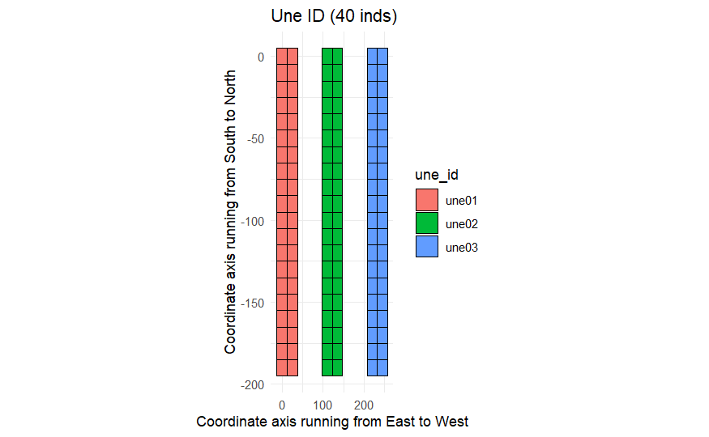

```r
ggplot(spatial_info, aes(x = x_axis, y = y_axis, fill = une_id)) +
  geom_tile(color = "black", linewidth = 0.5) +
  labs(title = "Une ID (40 inds)",
       x = "Coordinate axis running from East to West",
       y = "Coordinate axis running from South to North") +
  coord_fixed(ratio = 4.0) +  # setting aspect ratio
  theme_minimal()
```

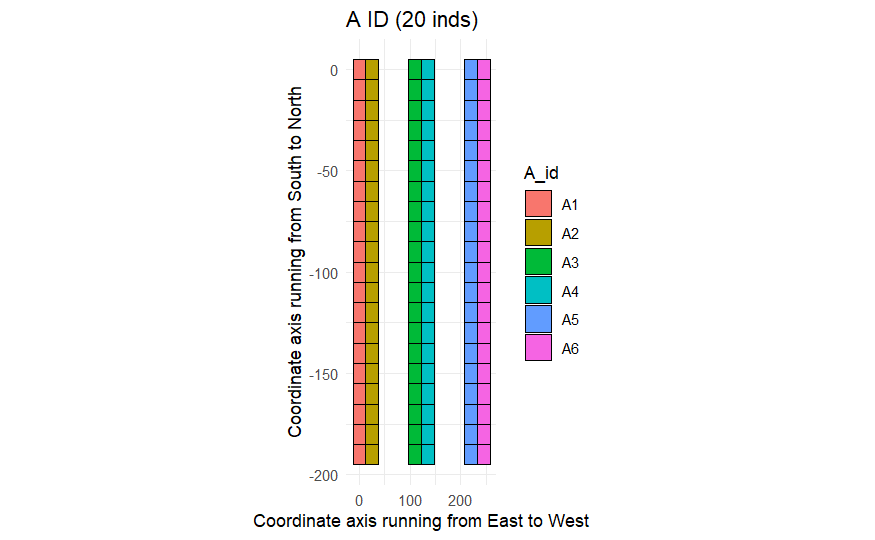

```r
ggplot(spatial_info, aes(x = x_axis, y = y_axis, fill = A_id)) +
  geom_tile(color = "black", linewidth = 0.5) +
  labs(title = "A ID (20 inds)",
       x = "Coordinate axis running from East to West",
       y = "Coordinate axis running from South to North") +
  coord_fixed(ratio = 4.0) +  # setting aspect ratio
  theme_minimal()
```

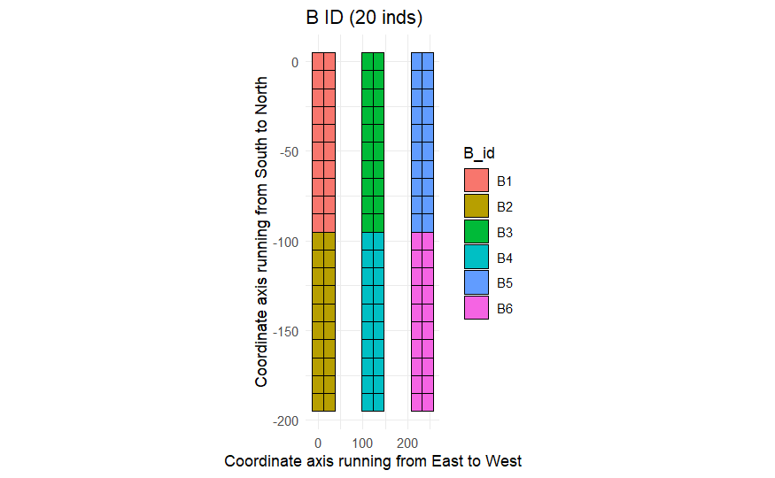

```r
ggplot(spatial_info, aes(x = x_axis, y = y_axis, fill = B_id)) +
  geom_tile(color = "black", linewidth = 0.5) +
  labs(title = "B ID (20 inds)",
       x = "Coordinate axis running from East to West",
       y = "Coordinate axis running from South to North") +
  coord_fixed(ratio = 4.0) +  # setting aspect ratio
  theme_minimal()
```

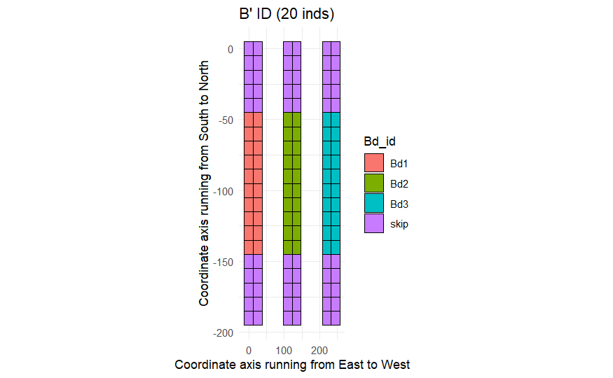

```r
ggplot(spatial_info, aes(x = x_axis, y = y_axis, fill = Bd_id)) +
  geom_tile(color = "black", linewidth = 0.5) +
  labs(title = "B' ID (20 inds)",
       x = "Coordinate axis running from East to West",
       y = "Coordinate axis running from South to North") +
  coord_fixed(ratio = 4.0) +  # setting aspect ratio
  theme_minimal()
```

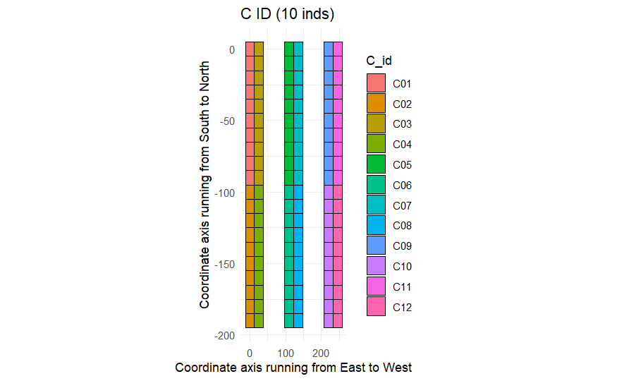

```r
ggplot(spatial_info, aes(x = x_axis, y = y_axis, fill = C_id)) +
  geom_tile(color = "black", linewidth = 0.5) +
  labs(title = "C ID (10 inds)",
       x = "Coordinate axis running from East to West",
       y = "Coordinate axis running from South to North") +
  coord_fixed(ratio = 4.0) +  # setting aspect ratio
  theme_minimal()
```

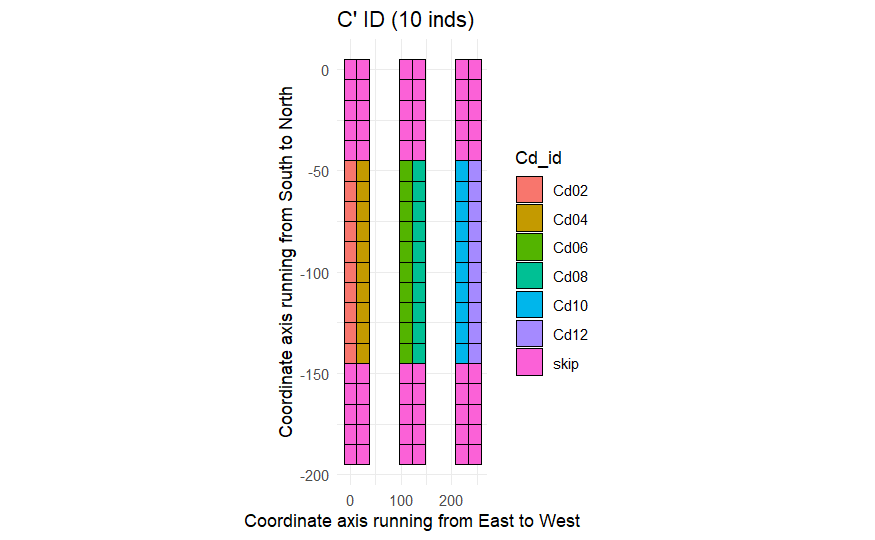

```r
ggplot(spatial_info, aes(x = x_axis, y = y_axis, fill = Cd_id)) +
  geom_tile(color = "black", linewidth = 0.5) +
  labs(title = "C' ID (10 inds)",
       x = "Coordinate axis running from East to West",
       y = "Coordinate axis running from South to North") +
  coord_fixed(ratio = 4.0) +  # setting aspect ratio
  theme_minimal()
```

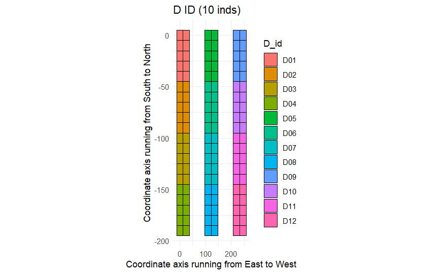

```r
ggplot(spatial_info, aes(x = x_axis, y = y_axis, fill = D_id)) +
  geom_tile(color = "black", linewidth = 0.5) +
  labs(title = "D ID (10 inds)",
       x = "Coordinate axis running from East to West",
       y = "Coordinate axis running from South to North") +
  coord_fixed(ratio = 4.0) +  # setting aspect ratio
  theme_minimal()
```

#### [1.4.2] Adding spatial stratification IDs into the data sumamry dataframe

```r
aphid2024april_v2 <- data.frame(aphid2024april,
                                une_id = spatial_info$une_id,
                                A_id = spatial_info$A_id,
                                B_id = spatial_info$B_id,
                                Bd_id = spatial_info$Bd_id,
                                C_id = spatial_info$C_id,
                                Cd_id = spatial_info$Cd_id,
                                D_id = spatial_info$D_id
                                )
aphid2024april_v2
```

| dayID | YY.MM.DD | month | day | dayN | x | y | section | intrasection_plantID | aphid | une_id | A_id | B_id | Bd_id | C_id | Cd_id | D_id |
| --- | --- | --- | --- | --- | --- | --- | --- | --- | --- | --- | --- | --- | --- | --- | --- | --- |
| s01 | 24-04-04 | M04 | D04 | 4 | 0 | 0 | sec01 | ind001 | 0 | une01 | A1 | B1 | skip | C01 | skip | D01 |
| s01 | 24-04-04 | M04 | D04 | 4 | 0 | -10 | sec01 | ind002 | 1 | une01 | A1 | B1 | skip | C01 | skip | D01 |
| s01 | 24-04-04 | M04 | D04 | 4 | 0 | -20 | sec01 | ind003 | 0 | une01 | A1 | B1 | skip | C01 | skip | D01 |
| s01 | 24-04-04 | M04 | D04 | 4 | 0 | -30 | sec01 | ind004 | 0 | une01 | A1 | B1 | skip | C01 | skip | D01 |
| s01 | 24-04-04 | M04 | D04 | 4 | 0 | -40 | sec01 | ind005 | 0 | une01 | A1 | B1 | skip | C01 | skip | D01 |
| s01 | 24-04-04 | M04 | D04 | 4 | 0 | -50 | sec01 | ind006 | 0 | une01 | A1 | B1 | Bd1 | C01 | Cd02 | D02 |
| s01 | 24-04-04 | M04 | D04 | 4 | 0 | -60 | sec01 | ind007 | 0 | une01 | A1 | B1 | Bd1 | C01 | Cd02 | D02 |
| s01 | 24-04-04 | M04 | D04 | 4 | 0 | -70 | sec01 | ind008 | 0 | une01 | A1 | B1 | Bd1 | C01 | Cd02 | D02 |
| s01 | 24-04-04 | M04 | D04 | 4 | 0 | -80 | sec01 | ind009 | 1 | une01 | A1 | B1 | Bd1 | C01 | Cd02 | D02 |
| s01 | 24-04-04 | M04 | D04 | 4 | 0 | -90 | sec01 | ind010 | 11 | une01 | A1 | B1 | Bd1 | C01 | Cd02 | D02 |

[output cut: 990 more lines]

## [2] Non-spatial data summary at the section level

### [2.1] Data stratification

```r
# splitting the data set into the list based on the monitoring date ID and section name
split_data <- split(aphid2024april$aphid, list(aphid2024april$dayID, aphid2024april$section))
# monitoring date ID at section level
split_dayN <- split(aphid2024april$dayN, list(aphid2024april$dayID, aphid2024april$section))
split_dayN <- lapply(split_dayN, mean)

# population size at the section level
split_sum <- lapply(split_data, sum)
# prevalence at the section level (0-1)
split_prev <- lapply(split_data, prevalence)

# standardized morisita index at the section level
split_morisita <- lapply(split_data, dispindmorisita)
# extracting the index value only
std_morisita <- sapply(split_morisita, function(df) df[1, 4])

# Converting list into dataframe
# Summarizing based on the monitoring date ID and section name
comb <- names(split_sum)
comb <- do.call(rbind, strsplit(comb, split = "\\."))

# Summarizing into dataframe
summary_aphid <- data.frame(
  dayID = comb[, 1],
  section = comb[, 2],
  dayN = unlist(split_dayN),
  popsize = unlist(split_sum),
  prevalence = unlist(split_prev),
  std_mi = std_morisita
)

# check the result
print(summary_aphid)
```

|  | dayID | section | dayN | popsize | prevalence | std_mi |
| --- | --- | --- | --- | --- | --- | --- |
| s01.sec01 | s01 | sec01 | 4 | 15 | 0.04166667 | 0.7551893 |
| s02.sec01 | s02 | sec01 | 8 | 45 | 0.05833333 | 0.6105497 |
| s03.sec01 | s03 | sec01 | 12 | 50 | 0.03333333 | 0.6192392 |
| s04.sec01 | s04 | sec01 | 15 | 73 | 0.11666667 | 0.5963550 |
| s05.sec01 | s05 | sec01 | 19 | 384 | 0.30833333 | 0.5327758 |
| s06.sec01 | s06 | sec01 | 22 | 649 | 0.46666667 | 0.5279340 |
| s07.sec01 | s07 | sec01 | 26 | 2144 | 0.62500000 | 0.5200849 |
| s08.sec01 | s08 | sec01 | 30 | 6358 | 0.70833333 | 0.5174303 |
| s01.sec02 | s01 | sec02 | 4 | 23 | 0.06666667 | 0.6045468 |
| s02.sec02 | s02 | sec02 | 8 | 107 | 0.15833333 | 0.5697429 |

[output cut: 22 more lines]

– Data stratification for calculating growth rate

```r
split_popl_growth <- split(summary_aphid$popsize, summary_aphid$section)
split_prev_growth <- split(summary_aphid$prevalence, summary_aphid$section)
split_morisita_growth <- split(summary_aphid$std_mi, summary_aphid$section)
split_dayN2 <- split(summary_aphid$dayN, summary_aphid$section)
```

### [2.2] Calculating the growth rate

#### [2.2.1] With tau = 0 (the past growth)

- But we don’t use it.

```r
popl_growth_list_0 <- mapply(specific_growth, split_popl_growth, split_dayN2, MoreArgs = list(tau = 0), SIMPLIFY = FALSE)
prev_growth_list_0 <- mapply(specific_growth, split_prev_growth, split_dayN2, MoreArgs = list(tau = 0), SIMPLIFY = FALSE)
```

#### [2.2.2] With tau = 1 (the growth to the next step)

```r
popl_growth_list_1 <- mapply(specific_growth, split_popl_growth, split_dayN2, MoreArgs = list(tau = 1), SIMPLIFY = FALSE)
prev_growth_list_1 <- mapply(specific_growth, split_prev_growth, split_dayN2, MoreArgs = list(tau = 1), SIMPLIFY = FALSE)
```

#### [2.2.3] With tau = 2 (the growth from the next step)

- But we don’t use it.

```r
popl_growth_list_2 <- mapply(specific_growth, split_popl_growth, split_dayN2, MoreArgs = list(tau = 2), SIMPLIFY = FALSE)
prev_growth_list_2 <- mapply(specific_growth, split_prev_growth, split_dayN2, MoreArgs = list(tau = 2), SIMPLIFY = FALSE)
```

- Adding rate info into the existing dataframe

```r
summary_aphid$popl_growth_0 = unlist(prev_growth_list_0)
summary_aphid$popl_growth_1 = unlist(prev_growth_list_1)
summary_aphid$popl_growth_2 = unlist(prev_growth_list_2)
summary_aphid$prev_growth_0 = unlist(prev_growth_list_0)
summary_aphid$prev_growth_1 = unlist(prev_growth_list_1)
summary_aphid$prev_growth_2 = unlist(prev_growth_list_2)

print(summary_aphid)
```

|  | dayID | section | dayN | popsize | prevalence | std_mi | popl_growth_0 | popl_growth_1 | popl_growth_2 | prev_growth_0 | prev_growth_1 | prev_growth_2 |
| --- | --- | --- | --- | --- | --- | --- | --- | --- | --- | --- | --- | --- |
| s01.sec01 | s01 | sec01 | 4 | 15 | 0.04166667 | 0.7551893 | NA | 0.084118059 | -0.13990395 | NA | 0.084118059 | -0.13990395 |
| s02.sec01 | s02 | sec01 | 8 | 45 | 0.05833333 | 0.6105497 | 0.084118059 | -0.139903947 | 0.41758766 | 0.084118059 | -0.139903947 | 0.41758766 |
| s03.sec01 | s03 | sec01 | 12 | 50 | 0.03333333 | 0.6192392 | -0.139903947 | 0.417587656 | 0.24296515 | -0.139903947 | 0.417587656 | 0.24296515 |
| s04.sec01 | s04 | sec01 | 15 | 73 | 0.11666667 | 0.5963550 | 0.417587656 | 0.242965146 | 0.13814459 | 0.417587656 | 0.242965146 | 0.13814459 |
| s05.sec01 | s05 | sec01 | 19 | 384 | 0.30833333 | 0.5327758 | 0.242965146 | 0.138144593 | 0.07303411 | 0.242965146 | 0.138144593 | 0.07303411 |
| s06.sec01 | s06 | sec01 | 22 | 649 | 0.46666667 | 0.5279340 | 0.138144593 | 0.073034106 | 0.03129079 | 0.138144593 | 0.073034106 | 0.03129079 |
| s07.sec01 | s07 | sec01 | 26 | 2144 | 0.62500000 | 0.5200849 | 0.073034106 | 0.031290786 | NA | 0.073034106 | 0.031290786 | NA |
| s08.sec01 | s08 | sec01 | 30 | 6358 | 0.70833333 | 0.5174303 | 0.031290786 | NA | NA | 0.031290786 | NA | NA |
| s01.sec02 | s01 | sec02 | 4 | 23 | 0.06666667 | 0.6045468 | NA | 0.216249359 | 0.03665087 | NA | 0.216249359 | 0.03665087 |
| s02.sec02 | s02 | sec02 | 8 | 107 | 0.15833333 | 0.5697429 | 0.216249359 | 0.036650869 | 0.13515504 | 0.216249359 | 0.036650869 | 0.13515504 |

[output cut: 22 more lines]

## [3] Non-spatial data summary at the une level

### [3.1] Data stratification

```r
# splitting the data set into the list based on the monitoring date ID nad section & une names
split_data_une <- split(aphid2024april_v2$aphid, list(aphid2024april_v2$dayID, aphid2024april_v2$une_id, aphid2024april_v2$section))
# monitoring date ID
split_dayN_une <- split(aphid2024april_v2$dayN, list(aphid2024april_v2$dayID, aphid2024april_v2$une_id, aphid2024april_v2$section))
split_dayN_une <- lapply(split_dayN_une, mean)

# population size at the une level
split_sum_une <- lapply(split_data_une, sum)
# prevalence at the une level (0-1)
split_prev_une <- lapply(split_data_une, prevalence)

# standardized morisita index at the section level
split_morisita_une <- lapply(split_data_une, dispindmorisita)
# extracting the index value only
std_morisita_une <- sapply(split_morisita_une, function(df) df[1, 4])


# Converting list into dataframe
# Summarizing based on the monitoring date ID and section & une names

comb_une <- names(split_sum_une)
comb_une <- do.call(rbind, strsplit(comb_une, split = "\\."))

# Summarizing into the new dataframe
summary_aphid_apr_une <- data.frame(
  dayID = comb_une[, 1],
  une = comb_une[, 2],
  section = comb_une[, 3],
  une_section = paste(comb_une[, 2], comb_une[, 3], sep = "."),
  dayN = unlist(split_dayN_une),
  popsize_une = unlist(split_sum_une),
  prevalence_une = unlist(split_prev_une),
  std_mi_une = std_morisita_une
)
print(summary_aphid_apr_une)
```

|  | dayID | une | section | une_section | dayN | popsize_une | prevalence_une | std_mi_une |
| --- | --- | --- | --- | --- | --- | --- | --- | --- |
| s01.une01.sec01 | s01 | une01 | sec01 | une01.sec01 | 4 | 14 | 0.100 | 0.78917530 |
| s02.une01.sec01 | s02 | une01 | sec01 | une01.sec01 | 8 | 14 | 0.025 | 1.00000000 |
| s03.une01.sec01 | s03 | une01 | sec01 | une01.sec01 | 12 | 13 | 0.025 | 1.00000000 |
| s04.une01.sec01 | s04 | une01 | sec01 | une01.sec01 | 15 | 19 | 0.100 | 0.64854730 |
| s05.une01.sec01 | s05 | une01 | sec01 | une01.sec01 | 19 | 90 | 0.325 | 0.56622671 |
| s06.une01.sec01 | s06 | une01 | sec01 | une01.sec01 | 22 | 172 | 0.450 | 0.61107883 |
| s07.une01.sec01 | s07 | une01 | sec01 | une01.sec01 | 26 | 849 | 0.625 | 0.55978312 |
| s08.une01.sec01 | s08 | une01 | sec01 | une01.sec01 | 30 | 710 | 0.700 | 0.55017257 |
| s01.une02.sec01 | s01 | une02 | sec01 | une02.sec01 | 4 | 0 | 0.000 | NaN |
| s02.une02.sec01 | s02 | une02 | sec01 | une02.sec01 | 8 | 16 | 0.050 | 0.93373153 |

[output cut: 86 more lines]

– Data stratification for calculating growth rate

```r
split_popl_growth_une <- split(summary_aphid_apr_une$popsize_une, list(summary_aphid_apr_une$une, summary_aphid_apr_une$section))
split_prev_growth_une <- split(summary_aphid_apr_une$prevalence_une, list(summary_aphid_apr_une$une, summary_aphid_apr_une$section))
split_dayN2_une <- split(summary_aphid_apr_une$dayN, list(summary_aphid_apr_une$une, summary_aphid_apr_une$section))
```

### [3.2] Calculating growth rate

#### [3.2.1] With tau = 0

```r
popl_growth_list_une_0 <- mapply(specific_growth, split_popl_growth_une, split_dayN2_une, MoreArgs = list(tau = 0), SIMPLIFY = FALSE)
prev_growth_list_une_0 <- mapply(specific_growth, split_prev_growth_une, split_dayN2_une, MoreArgs = list(tau = 0), SIMPLIFY = FALSE)
```

#### [3.2.2] With tau = 1

```r
popl_growth_list_une_1 <- mapply(specific_growth, split_popl_growth_une, split_dayN2_une, MoreArgs = list(tau = 1), SIMPLIFY = FALSE)
prev_growth_list_une_1 <- mapply(specific_growth, split_prev_growth_une, split_dayN2_une, MoreArgs = list(tau = 1), SIMPLIFY = FALSE)
```

#### [3.2.3] With tau = 2

```r
popl_growth_list_une_2 <- mapply(specific_growth, split_popl_growth_une, split_dayN2_une, MoreArgs = list(tau = 2), SIMPLIFY = FALSE)
prev_growth_list_une_2 <- mapply(specific_growth, split_prev_growth_une, split_dayN2_une, MoreArgs = list(tau = 2), SIMPLIFY = FALSE)
```

- Adding rate info into the existing dataframe

```r
summary_aphid_apr_une$popl_growth_une_0 = unlist(popl_growth_list_une_0)
summary_aphid_apr_une$popl_growth_une_1 = unlist(popl_growth_list_une_1)
summary_aphid_apr_une$popl_growth_une_2 = unlist(popl_growth_list_une_2)
summary_aphid_apr_une$prev_growth_une_0 = unlist(prev_growth_list_une_0)
summary_aphid_apr_une$prev_growth_une_1 = unlist(prev_growth_list_une_1)
summary_aphid_apr_une$prev_growth_une_2 = unlist(prev_growth_list_une_2)

print(summary_aphid_apr_une)
```

|  | dayID | une | section | une_section | dayN | popsize_une | prevalence_une | std_mi_une | popl_growth_une_0 | popl_growth_une_1 | popl_growth_une_2 | prev_growth_une_0 | prev_growth_une_1 | prev_growth_une_2 |
| --- | --- | --- | --- | --- | --- | --- | --- | --- | --- | --- | --- | --- | --- | --- |
| s01.une01.sec01 | s01 | une01 | sec01 | une01.sec01 | 4 | 14 | 0.100 | 0.78917530 | NA | 0.000000000 | -0.018526993 | NA | -0.346573590 | 0.000000000 |
| s02.une01.sec01 | s02 | une01 | sec01 | une01.sec01 | 8 | 14 | 0.025 | 1.00000000 | 0.000000000 | -0.018526993 | 0.126496541 | -0.346573590 | 0.000000000 | 0.462098120 |
| s03.une01.sec01 | s03 | une01 | sec01 | une01.sec01 | 12 | 13 | 0.025 | 1.00000000 | -0.018526993 | 0.126496541 | 0.388842673 | 0.000000000 | 0.462098120 | 0.294663749 |
| s04.une01.sec01 | s04 | une01 | sec01 | une01.sec01 | 15 | 19 | 0.100 | 0.64854730 | 0.126496541 | 0.388842673 | 0.215894935 | 0.462098120 | 0.294663749 | 0.108474133 |
| s05.une01.sec01 | s05 | une01 | sec01 | une01.sec01 | 19 | 90 | 0.325 | 0.56622671 | 0.388842673 | 0.215894935 | 0.399141177 | 0.294663749 | 0.108474133 | 0.082126017 |
| s06.une01.sec01 | s06 | une01 | sec01 | une01.sec01 | 22 | 172 | 0.450 | 0.61107883 | 0.215894935 | 0.399141177 | -0.044698554 | 0.108474133 | 0.082126017 | 0.028332171 |
| s07.une01.sec01 | s07 | une01 | sec01 | une01.sec01 | 26 | 849 | 0.625 | 0.55978312 | 0.399141177 | -0.044698554 | NA | 0.082126017 | 0.028332171 | NA |
| s08.une01.sec01 | s08 | une01 | sec01 | une01.sec01 | 30 | 710 | 0.700 | 0.55017257 | -0.044698554 | NA | NA | 0.028332171 | NA | NA |
| s01.une02.sec01 | s01 | une02 | sec01 | une02.sec01 | 4 | 0 | 0.000 | NaN | NA | NA | 0.121376954 | NA | NA | 0.000000000 |
| s02.une02.sec01 | s02 | une02 | sec01 | une02.sec01 | 8 | 16 | 0.050 | 0.93373153 | NA | 0.121376954 | 0.108474133 | NA | 0.000000000 | 0.135155036 |

[output cut: 86 more lines]

## [4] Visualization of time evolution w/o spatial info

### [4.1] Section level

– basic visualization

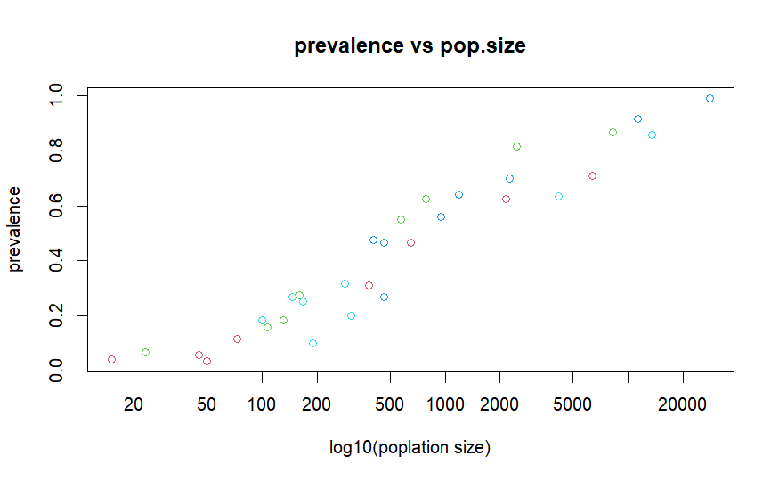

```r
plot(prevalence ~ popsize, log = "x", data = summary_aphid, main = "prevalence vs pop.size", xlab = "log10(poplation size)", ylab = "prevalence", col = as.numeric(as.factor(summary_aphid$section)) + 1)
```

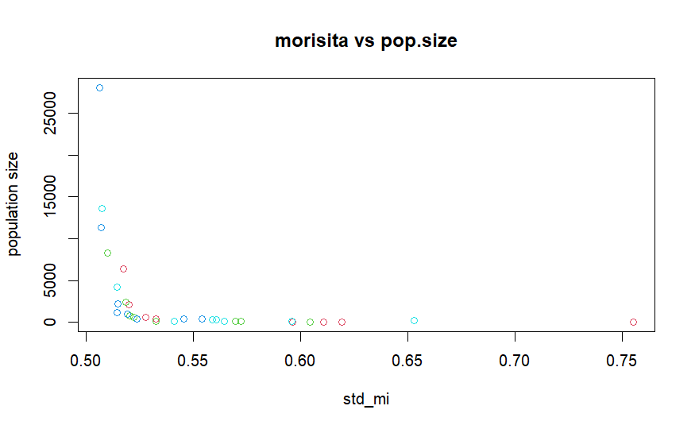

```r
plot(popsize ~ std_mi, data = summary_aphid, main = "morisita vs pop.size", xlab = "std_mi", ylab = "population size", col = as.numeric(as.factor(summary_aphid$section)) + 1)
```

```r
plot(popsize ~ std_mi, log = "y", data = summary_aphid, main = "morisita vs log10(pop.size)", xlab = "std_mi", ylab = "log10(poplation size)", col = as.numeric(as.factor(summary_aphid$section)) + 1)
abline(h = 100, col = 2, lty = "dashed")
```

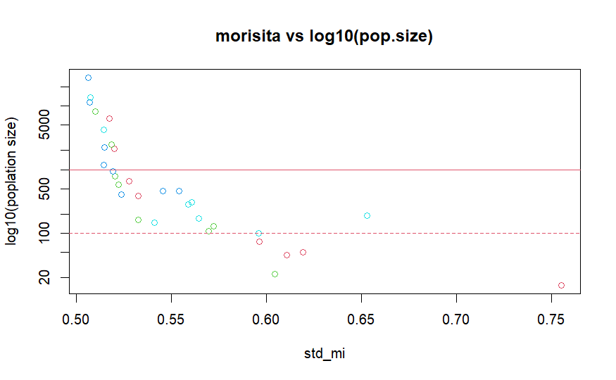

```r
abline(h = 1000, col = 2)
```

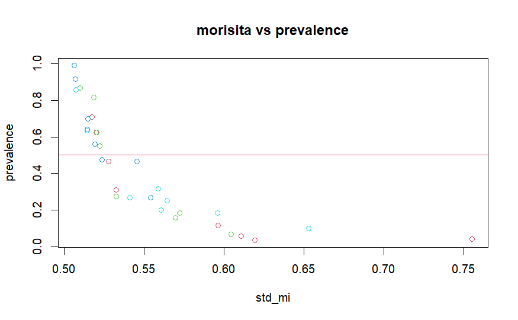

```r
plot(prevalence ~ std_mi, data = summary_aphid, main = "morisita vs prevalence", xlab = "std_mi", ylab = "prevalence", col = as.numeric(as.factor(summary_aphid$section)) + 1)
abline(h = 0.5, col = 2)
```

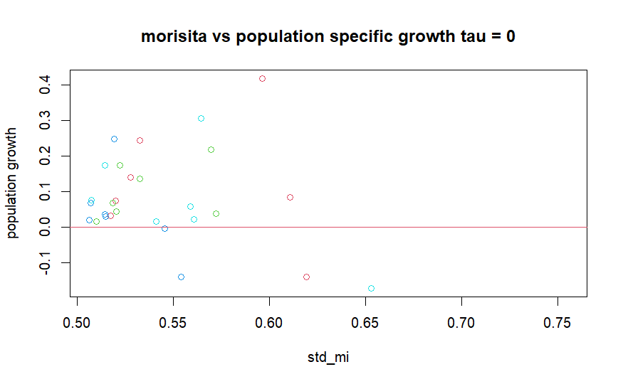

```r
plot(popl_growth_0 ~ std_mi, data = summary_aphid, main = "morisita vs population specific growth tau = 0", xlab = "std_mi", ylab = "population growth", col = as.numeric(as.factor(summary_aphid$section)) + 1)
abline(h = 0.0, col = 2)
```

```r
plot(prev_growth_0 ~ std_mi, data = summary_aphid, main = "morisita vs prevalence specific growth tau = 0", xlab = "std_mi", ylab = "prevalencec growth", col = as.numeric(as.factor(summary_aphid$section)) + 1)
abline(h = 0.0, col = 2)
```

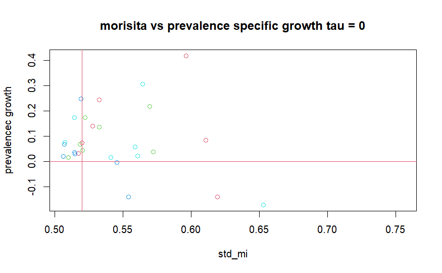

```r
abline(v = 0.52, col = 2)
```

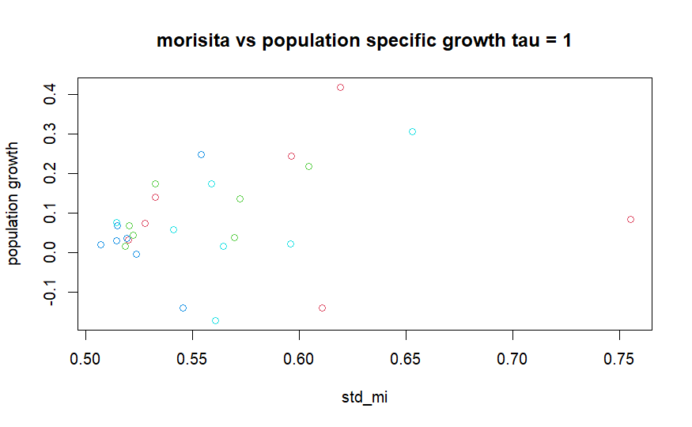

```r
plot(popl_growth_1 ~ std_mi, data = summary_aphid, main = "morisita vs population specific growth tau = 1", xlab = "std_mi", ylab = "population growth", col = as.numeric(as.factor(summary_aphid$section)) + 1)
```

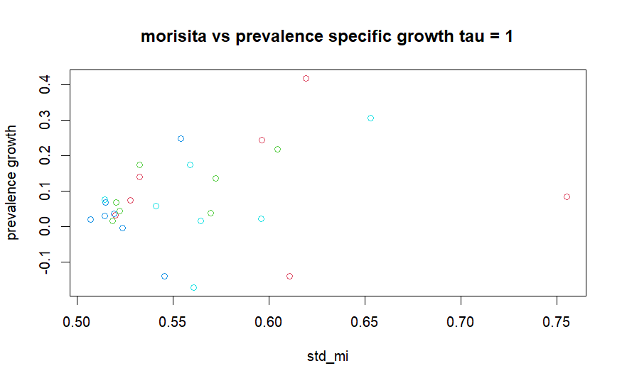

```r
plot(prev_growth_1 ~ std_mi, data = summary_aphid, main = "morisita vs prevalence specific growth tau = 1", xlab = "std_mi", ylab = "prevalence growth", col = as.numeric(as.factor(summary_aphid$section)) + 1)
```

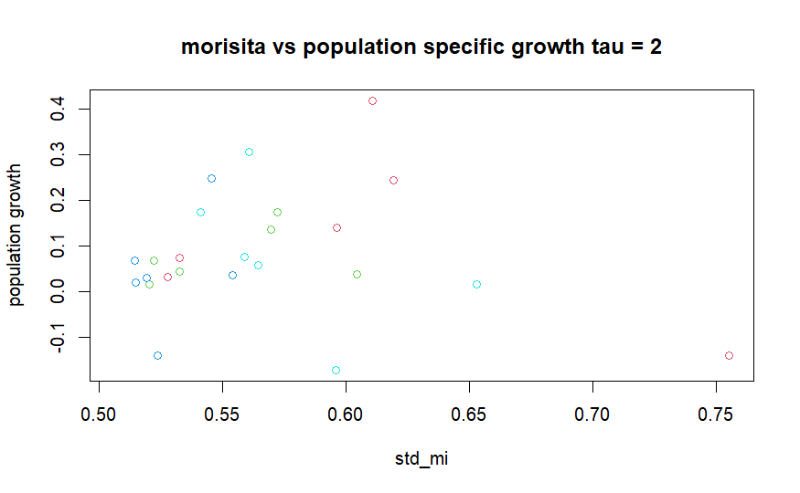

```r
plot(popl_growth_2 ~ std_mi, data = summary_aphid, main = "morisita vs population specific growth tau = 2", xlab = "std_mi", ylab = "population growth", col = as.numeric(as.factor(summary_aphid$section)) + 1)
```

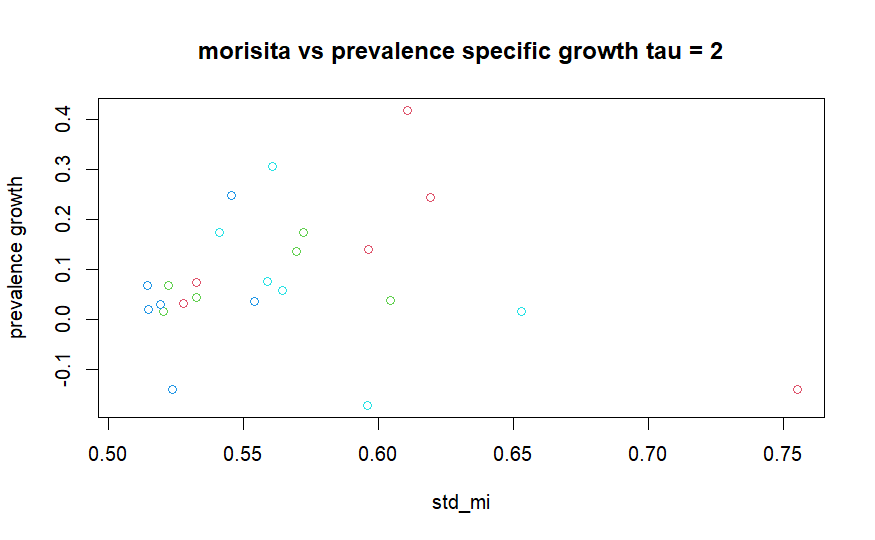

```r
plot(prev_growth_2 ~ std_mi, data = summary_aphid, main = "morisita vs prevalence specific growth tau = 2", xlab = "std_mi", ylab = "prevalence growth", col = as.numeric(as.factor(summary_aphid$section)) + 1)
```

#### [4.1.1] Time evolution at the section level

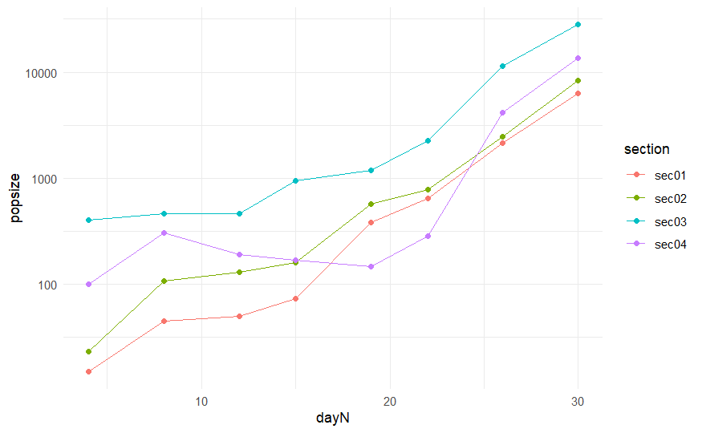

```r
ggplot(summary_aphid, aes(x = dayN, y = popsize, group = section, color = section)) +
  geom_line() +
  geom_point() +
  scale_y_log10() +
  theme_minimal()
```

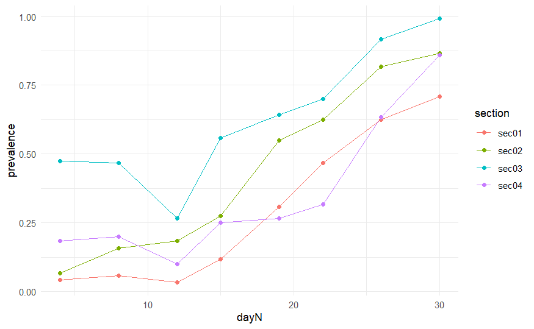

```r
ggplot(summary_aphid, aes(x = dayN, y = prevalence, group = section, color = section)) +
  geom_line() +
  geom_point() +
  theme_minimal()
```

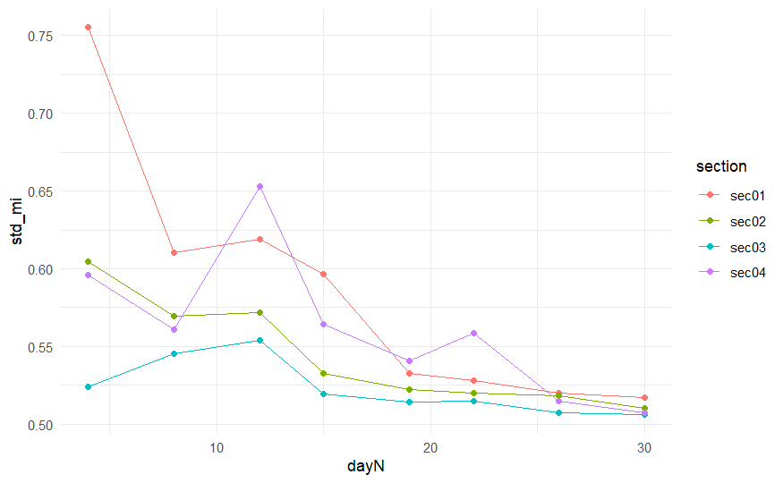

```r
ggplot(summary_aphid, aes(x = dayN, y = std_mi, group = section, color = section)) +
  geom_line() +
  geom_point() +
  theme_minimal()
```

#### [4.1.2] Focusing on morisita

– Morisita vs population size

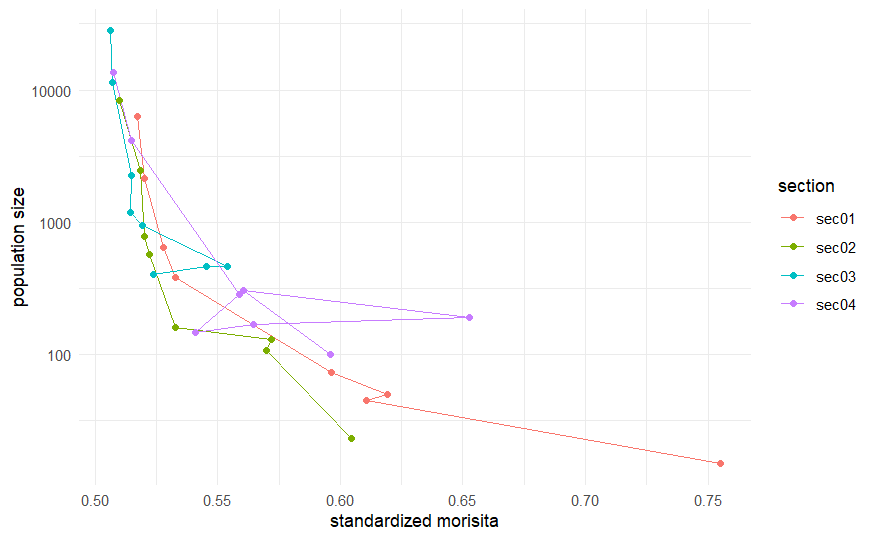

```r
ggplot(summary_aphid, aes(x = std_mi, y = popsize, group = section, color = section)) +
  geom_path() +
  geom_point() +
  scale_y_log10() +
  labs(x = "standardized morisita", y = "population size") +
  theme_minimal()
```

– Morisita vs prevalence

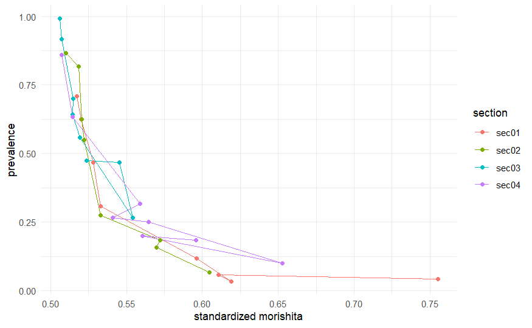

```r
ggplot(summary_aphid, aes(x = std_mi, y = prevalence, group = section, color = section)) +
  geom_path() +
  geom_point() +
  labs(x = "standardized morishita", y = "prevalence") +
  theme_minimal()
```

### [4.2] Une level

– basic visualization

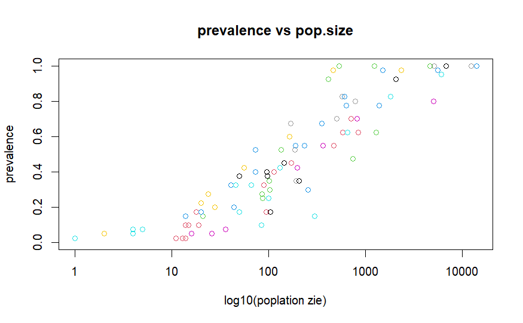

```r
plot(prevalence_une ~ popsize_une, log = "x", data = summary_aphid_apr_une, main = "prevalence vs pop.size", xlab = "log10(poplation zie)", ylab = "prevalence", col = as.numeric(as.factor(summary_aphid_apr_une$une_section)) + 1)
```

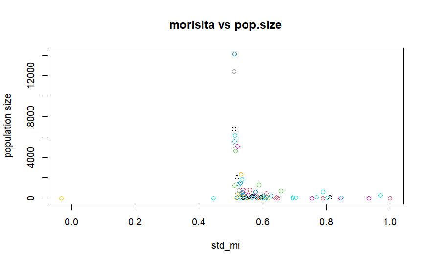

```r
plot(popsize_une ~ std_mi_une, data = summary_aphid_apr_une, main = "morisita vs pop.size", xlab = "std_mi", ylab = "population size", col = as.numeric(as.factor(summary_aphid_apr_une$une_section)) + 1)
```

```r
plot(popsize_une ~ std_mi_une, log = "y", data = summary_aphid_apr_une, main = "morisita vs log10(pop.size)", xlab = "std_mi", ylab = "log10(poplation size)", col = as.numeric(as.factor(summary_aphid_apr_une$une_section)) + 1)
abline(h = 100, col = 2, lty = "dashed")
```

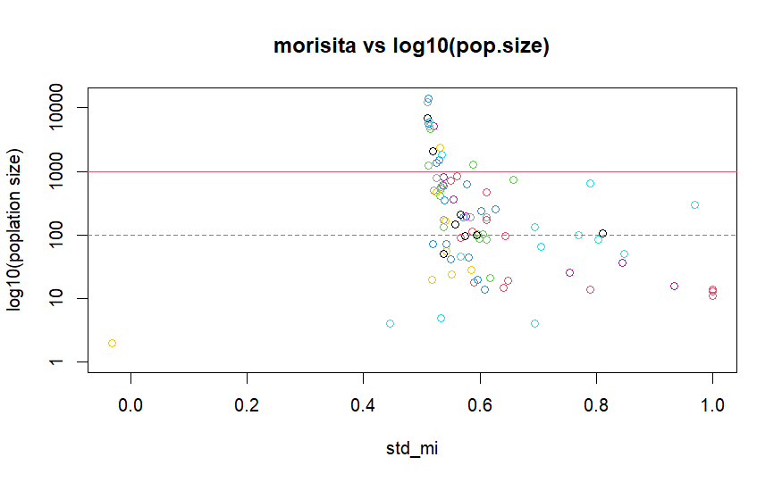

```r
abline(h = 1000, col = 2)
```

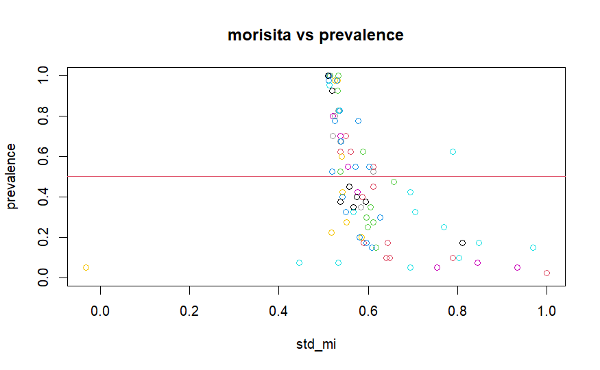

```r
plot(prevalence_une ~ std_mi_une, data = summary_aphid_apr_une, main = "morisita vs prevalence", xlab = "std_mi", ylab = "prevalence", col = as.numeric(as.factor(summary_aphid_apr_une$une_section)) + 1)
abline(h = 0.5, col = 2)
```

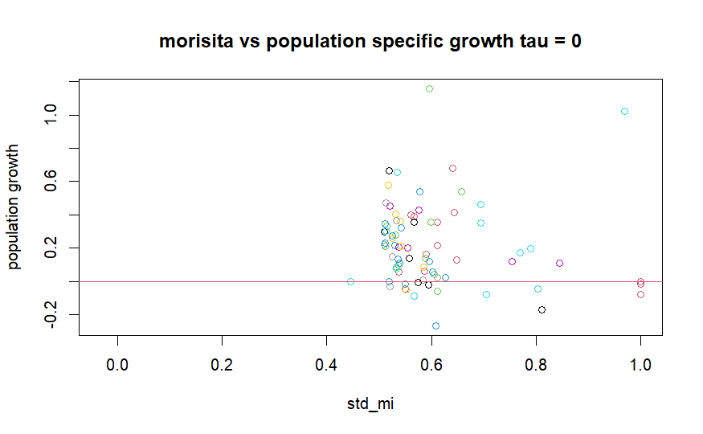

```r
plot(popl_growth_une_0 ~ std_mi_une, data = summary_aphid_apr_une, main = "morisita vs population specific growth tau = 0", xlab = "std_mi", ylab = "population growth", col = as.numeric(as.factor(summary_aphid_apr_une$une_section)) + 1)
abline(h = 0.0, col = 2)
```

```r
plot(prev_growth_une_0 ~ std_mi_une, data = summary_aphid_apr_une, main = "morisita vs prevalence specific growth tau = 0", xlab = "std_mi", ylab = "prevalencec growth", col = as.numeric(as.factor(summary_aphid_apr_une$une_section)) + 1)
abline(h = 0.0, col = 2)
```

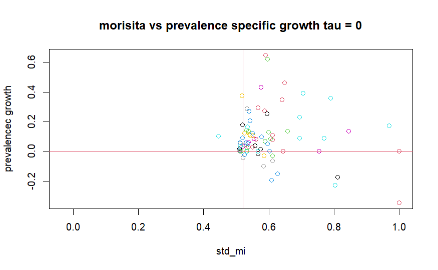

```r
abline(v = 0.52, col = 2)
```

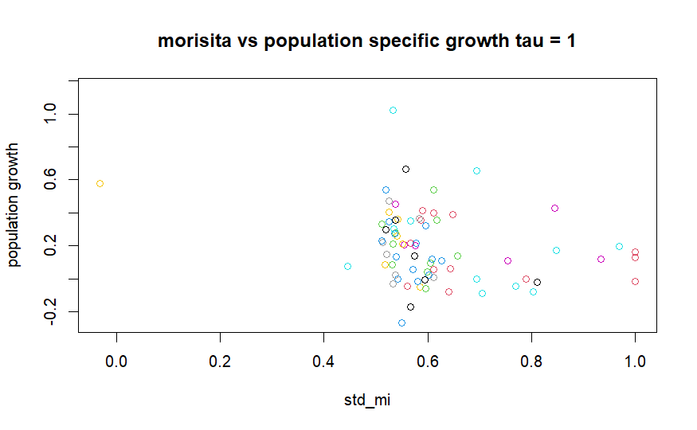

```r
plot(popl_growth_une_1 ~ std_mi_une, data = summary_aphid_apr_une, main = "morisita vs population specific growth tau = 1", xlab = "std_mi", ylab = "population growth", col = as.numeric(as.factor(summary_aphid_apr_une$une_section)) + 1)
```

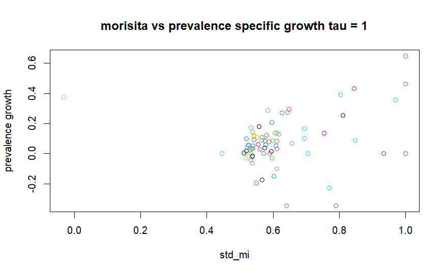

```r
plot(prev_growth_une_1 ~ std_mi_une, data = summary_aphid_apr_une, main = "morisita vs prevalence specific growth tau = 1", xlab = "std_mi", ylab = "prevalence growth", col = as.numeric(as.factor(summary_aphid_apr_une$une_section)) + 1)
```

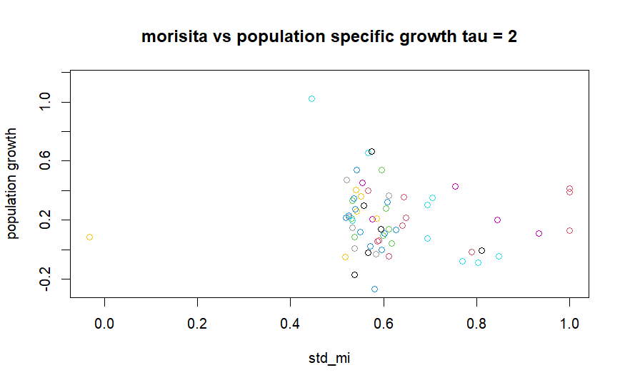

```r
plot(popl_growth_une_2 ~ std_mi_une, data = summary_aphid_apr_une, main = "morisita vs population specific growth tau = 2", xlab = "std_mi", ylab = "population growth", col = as.numeric(as.factor(summary_aphid_apr_une$une_section)) + 1)
```

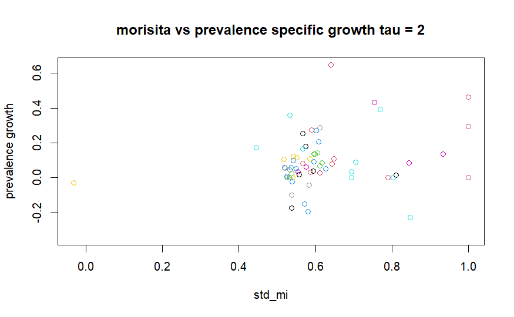

```r
plot(prev_growth_une_2 ~ std_mi_une, data = summary_aphid_apr_une, main = "morisita vs prevalence specific growth tau = 2", xlab = "std_mi", ylab = "prevalence growth", col = as.numeric(as.factor(summary_aphid_apr_une$une_section)) + 1)
```